# An End-to-End MFF Workflow

Nihat Tak and Sadık Çoban

2026-08-30

## Overview

The MFF package combines candidate regression predictions using weights obtained from clustering the candidates’ validation prediction profiles. Candidate models may be fitted with `model.train()`, generated by bootstrap resampling with `boot.train()`, or trained externally. In every case, MFF needs:

- a validation prediction matrix, with observations in rows and candidate models in columns;
- the validation response vector;
- a test prediction matrix whose columns represent the same candidates in the same order; and
- the test response only for final, unbiased performance reporting.

This vignette illustrates the complete bootstrap workflow. It deliberately selects the MFF configuration and cluster using validation data before inspecting test performance.

## Generate candidate predictions

We use the Boston housing data only as a compact reproducible illustration. `boot.train()` splits the data into training, validation, and test subsets, fits one linear regression to each bootstrap sample of the training subset, and predicts the same validation and test observations with every fitted model.

```r
library(MFF)

set.seed(123)
boot_fit <- boot.train(
  target = "medv",
  data = MASS::Boston,
  ntest = 50,
  nvalid = 50,
  B = 20,
  seed = 123,
  parallel = FALSE
)

dim(boot_fit$pred_matrix_valid)
```

```
#> [1] 50 20
```

```r
dim(boot_fit$pred_matrix_test)
```

```
#> [1] 50 20
```

```r
boot_fit$metadata
```

```
#> $ntrain
#> [1] 406
#>
#> $B
#> [1] 20
#>
#> $parallel
#> [1] FALSE
```

Each column is now a candidate learner. The two matrices are aligned: column `j` contains predictions from the same bootstrap model in both matrices.

## Select an MFF on validation data

`tune.mff()` searches over candidate numbers of clusters. Here k-means is used for a fast example; `"fcm"`, `"pfcm"`, and `"gk"` provide the alternative membership-generation geometries. The `eval.method` value determines which validation loss is minimized.

```r
tuned <- tune.mff(
  x = boot_fit$pred_matrix_valid,
  y = boot_fit$y_valid,
  max_c = 4,
  mff.method = "kmeans",
  eval.method = "RMSE",
  nstart = 20,
  seed = 123,
  parallel = FALSE,
  logging = FALSE
)

tuned$best_params
```

```
#> $c
#> [1] 3
#>
#> $nstart
#> [1] 20
```

```r
tuned$best_cluster
```

```
#> [1] 3
```

```r
tuned$best_scores
```

```
#>           MAE     RMSE     MAPE    SMAPE      MSE    MedAE
#> [1,] 3.802218 5.620469 20.27838 21.22602 31.58967 2.625498
#> [2,] 3.753815 5.779047 19.95525 20.99516 33.39738 2.699121
#> [3,] 3.616228 5.616796 19.37491 20.20522 31.54839 2.553211
```

The value in `best_cluster` is determined exclusively from validation responses. Consequently, the selected cluster is fixed before test responses or test error metrics are examined. The fact that a particular cluster later gives the best test result must not be used retrospectively to choose that cluster.

## Inspect the membership-derived weights

Standard `print()` and `summary()` methods report the fitted algorithm, dimensions, validation-selected function, and complete weight matrix. The same matrix can be displayed directly as a labelled heatmap. Rows are candidate models, columns are meta fuzzy functions, and darker cells indicate larger normalized contributions.

```r
print(tuned)
```

```
#> Meta Fuzzy Function object
#>   Algorithm: kmeans
#>   Candidate models: 20
#>   Meta functions: 3
#>   Selection metric: RMSE
#>   Validation-selected function: 3
```

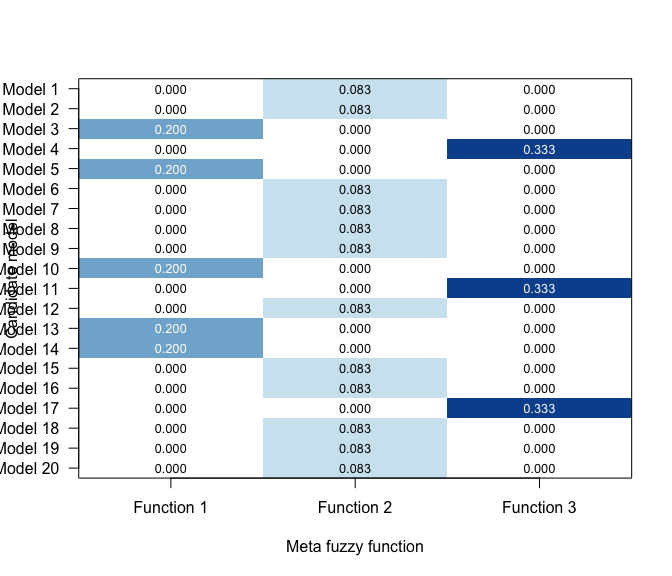

```r
plot(tuned, type = "weight_heatmap")
```

## Predict and evaluate once on the test set

The validation-selected weights are transferred unchanged to the aligned test prediction matrix.

```r
test_prediction <- predict(
  tuned,
  pred_matrix = boot_fit$pred_matrix_test,
  type = "best"
)

head(test_prediction$mff_preds)
```

```
#>         [,1]
#> 340 21.15798
#> 455 14.19619
#> 246 13.19929
#> 183 33.65597
#> 238 32.79183
#> 318 18.63110
```

```r
test_prediction$mff_weights
```

```
#>  [1] 0.0000 0.0000 0.0000 0.3333 0.0000 0.0000 0.0000 0.0000 0.0000 0.0000
#> [11] 0.3333 0.0000 0.0000 0.0000 0.0000 0.0000 0.3333 0.0000 0.0000 0.0000
```

Only after selection is complete do we use `y_test` for final evaluation.

```r
evaluate(test_prediction$mff_preds, boot_fit$y_test)
```

```
#>           MAE     RMSE    MAPE    SMAPE      MSE    MedAE
#> [1,] 1.971028 2.729576 9.72003 9.902715 7.450586 1.507598
```

The `evaluate()` helper is optional. Predictions can instead be assessed with other R packages or user-defined metrics, provided that model selection remains confined to the validation data.

## Supplying predictions from other R workflows

Neither `boot.train()` nor `model.train()` is required. Learners may be trained with packages such as `tidymodels`, `caret`, `mlr3`, or forecasting packages. For externally generated inputs, users must ensure that:

1. validation predictions are genuinely out of sample for model selection;
2. validation and test matrices have the same candidate columns in the same order;
3. rows align exactly with the corresponding response vectors; and
4. for forecasting applications, train-validation-test splits respect temporal order and do not leak future information.

Once these conditions are met, the downstream interface is unchanged:

```r
tuned <- tune.mff(
  x = validation_predictions,
  y = validation_response,
  max_c = 4,
  mff.method = "gk",
  eval.method = "RMSE"
)

final_prediction <- predict(
  tuned,
  pred_matrix = test_predictions,
  type = "best"
)
```

Thus MFF can combine heterogeneous regression or forecasting candidates without requiring those candidates to have been trained inside the package.